# Pasivno zamijenjena: cijena inflacije koju ne mjeri indeks potrošačkih cijena

Institucionalni jaz u pažnji HNB-a, 2021.-2026.

Authors

Affiliation

Petra Palić

Hrvatsko katoličko sveučilište

Luka Sikić

Hrvatsko katoličko sveučilište

Published

28. 9. 2026.

## Sažetak

Kako se relativna medijska zastupljenost središnje banke mijenja s inflacijom? Na hrvatskom korpusu digitalnih objava konstruiramo institucionalni jaz u pažnji HNB-a kao razliku između početnog i tekućeg ponderiranog udjela u inflacijskom diskursu. Arhiv obuhvaća razdoblje od 1. siječnja 2021. do 10. rujna 2026.; glavne mjesečne procjene koriste svih 68 potpunih mjeseci do kolovoza 2026. Jedan postotni bod više inflacije povezan je s 0,25 postotnih bodova većim jazom u tjednom modelu, uz 95-postotni interval od 0,11 do 0,39. Mjesečni koeficijent iznosi 0,27 postotnih bodova. Nalaz je postojan kroz alternativne definicije korpusa i dosega, ali uz godišnje indikatore nije statistički razlučiv od nule. Najjasnija povezanost odnosi se na relativni broj relevantnih objava; ne nalazimo stabilnu vezu jaza s budućim anketnim očekivanjima. Mjera opisuje zastupljenost institucije u prikupljenom medijskom korpusu. Potencijalni doseg, mrežna centralnost i anketna očekivanja ostaju različite empirijske veličine, pa iz medijskog udjela ne izvodimo zaključak o čitanosti, razumijevanju ili uzročnom učinku komunikacije.

Ključne riječi: institucionalni jaz u pažnji; HNB; inflacija; medijska zastupljenost; očekivanja potrošača; tekstualni podatci.

# 1 Uvod

Kada cijene postanu glavna gospodarska tema, središnja banka ne mora zauzeti veći dio javne rasprave. Vijesti o hrani, energiji, plaćama i državnim intervencijama mogu rasti brže od izvještavanja o monetarnoj politici. Institucija tada može biti prisutna u velikom broju objava, a ipak izgubiti relativni prostor unutar rasprave o inflaciji. Taj odnos između obujma gospodarskih vijesti i institucionalne zastupljenosti predmet je ovoga rada.

Ispitujemo hrvatski slučaj od 2021. do 2026., razdoblje koje obuhvaća inflacijski val, uvođenje eura i kasniju dezinflaciju. Analizu organiziramo oko triju pitanja. Prvo, kako je stopa inflacije povezana s ponderiranim udjelom HNB-a u inflacijskom diskursu? Drugo, odražava li se promjena udjela ponajprije u broju relevantnih objava, njihovu relativnom dosegu ili položaju HNB-a u medijskoj mreži? Treće, postoji li pouzdana vremenska veza između tako izmjerene zastupljenosti i anketnih očekivanja potrošača?

Pokazatelj institucionalnog jaza u pažnji (engl. *Institutional Attention Gap*, IAG) uspoređuje početni ponderirani udio HNB-a s njegovim udjelom u svakom kasnijem razdoblju. Objave dobivaju veći ponder kada institucija nastupa u naslovu, pojavljuje se rano i više puta te kada djeluje ili je navedena kao izvor. Ponder se zatim množi procjenom potencijalnog dosega. Takav postupak razlikuje središnju ulogu od usputnog spominjanja, ali ne pretvara medijski tekst u neposredno opažanje pažnje pojedinca.

Doprinos rada sastoji se u povezivanju transparentne tekstualne mjere s vremenskim nizom inflacije i u sustavnom razdvajanju njezinih mogućih tumačenja. Prikazujemo mjesečne i tjedne procjene, alternativne definicije objava i dosega, kontrole vremena, analizu dinamike te projekcije budućih anketnih odgovora. Za svaku usporedbu koristimo odgovarajući stvarni broj opažanja. Osnovne procjene pokazuju pozitivan odnos inflacije i jaza na obje frekvencije. Odnos je izraženiji uz kontrolu obujma institucionalnih objava, a godišnji indikatori povećavaju neizvjesnost procjene. Zato ga tumačimo kao uvjetnu povezanost kroz promatrano razdoblje. U kasnijim godinama udio institucije ostaje nizak, ali mrežni položaj ne pokazuje usporedivo trajno slabljenje; podaci ne podupiru poistovjećivanje tih dvaju ishoda.

Izraz „cijena inflacije” u naslovu označava mogući gubitak relativne zastupljenosti. Ne označava procijenjeni novčani trošak niti gubitak blagostanja. Jednako tako, veći jaz nije automatski pokazatelj slabije komunikacije: institucija može biti točno predstavljena u malom broju kvalitetnih tekstova, a relevantno se objašnjenje može prenijeti i bez njezina imenovanja.

# 2 Komunikacija, mediji i ograničena pažnja

## 2.1 Od institucionalne poruke do medijske zastupljenosti

Središnje banke djeluju kroz očekivanja o budućim cijenama, kamatnim stopama i gospodarskoj aktivnosti (Woodford, 2003). Međutim, raspoloživa informacija ne ulazi nužno u skup informacija koji pojedinac stvarno obrađuje. Racionalna nepažnja naglašava ograničen kapacitet obrade, dok pristup ljepljivih informacija dopušta neredovito ažuriranje informacija (Mankiw i Reis, 2002; Sims, 2003). Oba pristupa opravdavaju zasebno promatranje sadržaja poruke i njezine dostupnosti u medijskom prostoru.

Medijsko posredovanje uključuje odabir teme, sugovornika, naslova i citata. Gatekeeping objašnjava organizacijsku selekciju vijesti, a uokvirivanje način na koji odabrani elementi čine određeno tumačenje problema vidljivijim (Entman, 1993; Shoemaker i Vos, 2009). Stoga razlikujemo tri koraka: institucionalnu objavu, njezino predstavljanje u vijestima i reakciju publike. Ovaj rad neposredno mjeri drugi korak. Broj vlastitih objava HNB-a dodatna je kontrola prvoga koraka, dok anketni odgovori nude ograničenu provjeru trećega.

Eksperimentalna literatura o komunikaciji i očekivanjima pokazuje zašto reakciju kućanstava treba zasebno mjeriti (Coibion i sur., 2022). Iz činjenice da je institucija imenovana ne slijedi da je čitatelj susreo poruku, razumio je ili promijenio očekivanja. Naša mjera zato ne ulazi kao strukturni parametar u Phillipsovu krivulju i ne služi izravnoj procjeni monetarne transmisije.

## 2.2 Inflacijska pažnja i institucionalni udio

Rast interesa za cijene može povećati ukupni inflacijski diskurs bez razmjernog rasta zastupljenosti središnje banke. To je osnovna hipoteza relativnog istiskivanja. Literatura o pažnji pri različitim razinama inflacije motivira mogućnost da rast cijena mijenja intenzitet praćenja gospodarstva (Bracha i Tang, 2019). Ona sama ne određuje hoće li dodatna pažnja biti usmjerena prema instituciji, poduzećima, trgovinama ili državnim mjerama.

Drugo je pitanje oporavak nakon inflacijskog vala. Iskustva s inflacijom mogu imati dugotrajnije veze s očekivanjima (Malmendier i Nagel, 2016). U medijskom prostoru moguće je analogno zadržavanje tema i uredničkih rutina, ali takav mehanizam ovdje nije neposredno identificiran. Trend jaza tijekom 2024.-2026. koristimo kao opis uvjetne putanje, a ne kao dokaz histereze. Za histerezu bi trebalo pokazati da povijest šoka uzrokuje kasniju zastupljenost nakon odvajanja ostalih trajnih promjena.

# 3 Podatci i konstrukcija pokazatelja

## 3.1 Obuhvat i jedinice analize

Izvor je održavani arhiv hrvatskih digitalnih objava s datumom, naslovom, tekstom, oznakom izvora, vrstom platforme, potencijalnim dosegom i dobavljačevim sentimentom. Arhiv sadrži 42.267.474 zapisa na svih 2.079 datuma od 1. siječnja 2021. do 10. rujna 2026. To je opseg polazne baze, a ne broj objava koje ulaze u institucionalni brojnik. Odabir tematskoga i institucionalnoga korpusa provodi se istim pravilima kroz cijeli analizirani raspon.

Zadržavamo digitalne vrste izvora početne analize te isključujemo televiziju, radio, tisak, Bluesky i Threads. Na svim godinama primjenjujemo isto pravilo prisutnosti samostalne riječi „i” u naslovu, tijelu ili isječku, sukladno definiciji arhiva. Tako definirani korpus predstavlja opaženi digitalni prostor, a ne slučajni uzorak svih hrvatskih medija. Društvene objave i komentari mogu biti uključeni u zadržanim vrstama izvora; rezultate stoga ne opisujemo kao isključivo uredničke članke.

Primarni institucionalni korpus koristi formalni naziv Hrvatske narodne banke, kraticu HNB te oblike izraza „središnja banka” i „centralna banka”. Kratica se traži unutar naslova i tijela teksta uz granice riječi. Generički izrazi mogu označavati druge središnje banke. Zbog toga zasebno procjenjujemo užu varijantu koja zahtijeva izričit naziv HNB-a ili njegovu kraticu. Inflacijski korpus prepoznaje izraze povezane s inflacijom, cijenama, kamatama i monetarnom politikom; širi nazivnik dodaje povezane izraze o životnim troškovima i ekonomskim mjerama.

Ponovno izračunati institucionalni korpus sadrži 124.738 objava, od kojih je 65.836 relevantno za inflacijsku definiciju. Primarni mjesečni niz ima 68 potpunih mjeseci, a tjedni 296 potpunih tjedana s dostupnom inflacijom. Posljednji potpuni mjesec jest kolovoz 2026. Deset opaženih dana rujna ostaje u deskriptivnom izvozu; ne prikazuje se kao cijeli mjesec i ne nadomještamo još nedostupnu mjesečnu makroekonomsku vrijednost.

## 3.2 Istaknutost, doseg i relativni udio

Za objavu $i$ računamo ponder istaknutosti:

$$w_i=0{,}30T_i+0{,}25P_i+0{,}20F_i+0{,}25S_i. \qquad(1)$$

Komponenta $T_i$ označava prisutnost institucije u naslovu, $P_i$ raniji položaj prvoga spominjanja, $F_i$ rang učestalosti spominjanja po riječi, a $S_i$ jezičnu oznaku djelovanja ili navođenja izvora. Sve komponente nalaze se između nule i jedan. Rangovi, imputacijski medijani i granice ekstremnih dosega računaju se na cijelom analiziranom korpusu. Riječ je o retrospektivnoj mjeri prema unaprijed zadanim pravilima, a ne o procjeni čitateljeve pažnje niti o klasifikatoru validiranom ljudskim kodiranjem.

Potencijalni doseg $R_i$ dobavljačeva je procjena mogućeg dosega objave. Za nedostajuće ili nulte vrijednosti institucionalnog korpusa koristimo medijan izvora i duljinske kategorije teksta, zatim medijan izvora, a naposljetku ukupni medijan. Udio takvih imputacija iznosi 6,7 posto. Analiza osjetljivosti koristi samo opaženi doseg te ograničava ekstremne vrijednosti. Opaženi doseg nije broj jedinstvenih čitatelja; zbroj dosega može višestruko obuhvatiti istu osobu.

Ako objava nema uporabljiv tekst tijela, doprinos učestalosti spominjanja postavlja se na nulu; raspoloživi naslov i dalje može nositi informaciju. Podudaranje s inflacijskim korpusom preko URL-a zahtijeva neprazan identifikator.

Za skup relevantnih institucionalnih objava $\mathcal H_t$ i inflacijski korpus $\mathcal I_t$ definiramo:

$$s_t=\frac{\sum_{i\in\mathcal H_t}w_iR_i}{\sum_{j\in\mathcal I_t}R_j+1},\qquad IAG_t=\bar s-s_t. \qquad(2)$$

Jedinica u nazivniku stabilizira omjer. Referenca $\bar s$ prosjek je početnih udjela od siječnja do lipnja 2021., nakon uklanjanja početnih opažanja udaljenih više od dvije standardne devijacije od početnog prosjeka. Računa se zasebno po frekvenciji: mjesečno iznosi 4,923 posto, a tjedno 5,164 posto. Pozitivan jaz znači udio niži od reference; negativan jaz znači viši udio. Referenca nije poželjan ili optimalan cilj komunikacije.

Primjerice, uz nepromijenjeni ponderirani institucionalni doseg, povećanje ukupnog inflacijskog dosega smanjuje $s_t$. Zato veći jaz ne dokazuje da je HNB manje komunicirao. Promjena fiksne reference mijenja presjek regresije s konstantom, ali ne i nagib inflacije. Takvu promjenu baze ne predstavljamo kao neovisnu provjeru mehanizma.

## 3.3 Margine, mreža i vanjske serije

Ekstenzivna margina omjer je broja relevantnih institucionalnih objava i broja objava inflacijskog korpusa, uz jedinicu dodanu nazivniku. Intenzivna margina uspoređuje ponderirani doseg po relevantnoj institucionalnoj objavi s dosegom po objavi inflacijskog korpusa. Zbog korekcija nazivnika i razlika u ponderiranju njihov umnožak nije stroga računovodstvena dekompozicija jaza. Sirove koeficijente tih dvaju ishoda ne uspoređujemo kao da su u istoj mjernoj jedinici.

Mjesečna mreža povezuje medijske izvore i imenovane aktere. Projekcija na aktere koristi zajedničke izvore i ponderirane veze, iz čega računamo svojstvenu centralnost HNB-a. To je položaj u mreži izvora i aktera, a ne mreža međusobnoga čitanja ili dokaz da su akteri spomenuti u istoj rečenici. Tjednim opažanjima pridružuje se vrijednost mjeseca početka tjedna.

Hrvatska inflacija jest godišnja stopa promjene harmoniziranog indeksa potrošačkih cijena (HICP). Koristimo i prehrambenu i energetsku HICP inflaciju europodručja, nominalni FAO Food Price Index transformiran u godišnju promjenu (Food and Agriculture Organization of the United Nations, 2026) te bilancu odgovora hrvatskih potrošača o očekivanom kretanju cijena u sljedećih dvanaest mjeseci iz ankete Europske komisije. Anketna bilanca ne mjeri izravno dugoročnu usidrenost očekivanja.

Mjesečna inflacija ulazi u tjedni panel kao vrijednost mjeseca početka tjedna. Tjedna frekvencija stoga donosi dodatne opažaje medijskog sadržaja, ali ne stvara nove neovisne tjedne makroekonomske podatke. Anketnu bilancu analiziramo na izvornoj mjesečnoj frekvenciji te uz stepenasto i linearno pridruživanje tjednima. Linearna interpolacija koristi informacije susjednih mjesečnih točaka i ne predstavlja prognozu iz informacija raspoloživih u realnom vremenu.

# 4 Empirijska strategija

## 4.1 Osnovna jednadžba i inferencija

Osnovni model povezuje jaz s razinom i promjenom inflacije:

$$IAG_t=\alpha+\beta\pi_t+\theta\Delta\pi_t+\delta EURO_t+\gamma HHI_t+\lambda\log(1+N_t)+\varepsilon_t. \qquad(3)$$

$EURO_t$ označava razdoblje od siječnja 2023., $HHI_t$ koncentraciju potencijalnog dosega po izvorima institucionalnog korpusa, a $N_t$ broj objava toga korpusa. Kontrola obujma odnosi se na institucionalni korpus, ne na ukupni inflacijski nazivnik. Procjenjujemo i model bez obujma jer promjena broja institucionalnih objava može biti dio samog procesa koji želimo opisati. Razlika između tih koeficijenata nije identificirani posredovani učinak.

Standardne pogreške korigiramo za heteroskedastičnost i serijsku korelaciju Bartlettovim HAC postupkom (Newey i West, 1987). Osnovna širina iznosi cijeli dio kubnog korijena broja regresijskih opažanja. Prikazujemo 95-postotne intervale i dvostrane testove. Provjeravamo druge širine, grupiranje tjednih reziduala po mjesecima, izostavljanje pojedinih mjeseci i uvjetnu blokovnu permutaciju. Kod izostavljenoga mjeseca HAC koristi stvarne kalendarske udaljenosti preostalih opažanja.

Koeficijent $\beta$ opisuje uvjetnu povezanost. Ne identificira učinak egzogene promjene inflacije. Objavljivanje, izbor teme, institucionalna aktivnost i inflacija mogu zajednički reagirati na gospodarske događaje. Linearni trend, godišnji indikatori i sezonalnost služe provjerama koliko nalaz ovisi o vremenskoj strukturi. Godišnji indikatori zamjenjuju indikator eura jer je on njihova linearna kombinacija.

## 4.2 Alternativne mjere i vremenske projekcije

Analiza osjetljivosti mijenja institucionalnu identifikaciju, pondere istaknutosti, tretman dosega, opseg inflacijskog nazivnika i uključenost sindiciranih objava. U varijanti izvornih objava mijenja se institucionalni brojnik, dok nazivnik ostaje glavni inflacijski korpus. Ta provjera stoga nije potpuna deduplikacija cijelog medijskog sustava. Varijanta stalnih izvora zadržava 101 izvora s barem jednom relevantnom institucionalnom objavom u svakoj od šest kalendarskih godina, pri čemu isto ograničenje primjenjujemo na brojnik i nazivnik.

Sentiment je dobavljačeva automatska oznaka. Budući da nema neovisne validacije za istraživački zadatak, uključujemo ga kao dodatnu kontrolu, a ne kao uvjet obuhvata osnovne analize. Dodatne specifikacije uključuju vlastite objave HNB-a i udio objava o državnim cjenovnim i fiskalnim mjerama. Ti brojevi predstavljaju tekstualno definirane pokazatelje aktivnosti, a ne egzogene instrumente komunikacije.

Lokalnim projekcijama ispitujemo povezanost današnjega jaza ili ekstenzivne margine s budućom anketnom bilancom (Jordà, 2005). Osnovnim kontrolama dodajemo prethodnu vrijednost anketne bilance i prethodnu vrijednost promatranog medijskog pokazatelja. Procjenjujemo horizonte od nula do dvanaest razdoblja. Korekcija Bonferroni obuhvaća svih trinaest horizonata unutar pojedine kombinacije ishoda, izloženosti, frekvencije i specifikacije. Glavni tekst naglašava buduće horizonte jedan do dvanaest, a horizonte nula prikazuje kao istodobnu povezanost.

Prve razlike opisuju kratkoročno zajedničko kretanje. Jednadžba korekcije odstupanja dodatno uključuje prethodni rezidual odnosa među razinama i prethodnu promjenu jaza. Njezina brzina povratka je opisna: standardne pogreške drugoga koraka ne obuhvaćaju potpuno neizvjesnost prvoga koraka. IV procjene s eurozonskim cijenama hrane i energije te FAO indeksom služe dodatnoj osjetljivosti. Promjenu hrvatske inflacije u tim modelima tretiramo kao uključenu egzogenu kontrolu, što je dodatna pretpostavka. Usporedba s HANFA-om provjerava mogu li isti instrumenti predviđati zastupljenost druge financijske institucije i nakon kontrole hrvatske inflacije.

# 5 Rezultati

## 5.1 Putanja relativne zastupljenosti

Godišnji ponderirani udio institucionalnih objava u inflacijskom diskursu iznosi 6,12 posto 2021., spušta se na 3,59 posto u godini najviše prosječne inflacije, a 2023. raste na 4,67 posto. Broj relevantnih institucionalnih objava pritom raste s 8.419 u 2021. na 17.278 u 2022. To je ključna deskriptivna razlika: više relevantnih objava može pratiti manji relativni prostor kada inflacijski diskurs raste još brže.

Udio potom iznosi 3,26 posto 2024., 3,17 posto 2025. i 1,86 posto tijekom prvih osam mjeseci 2026. Putanja stoga ne pokazuje povratak godišnjeg udjela na razinu iz 2021. nakon vrhunca inflacije. Mjesečni udjeli znatno variraju, od 0,56 do 15,91 posto, pa se uz godišnje sažetke prikazuje cijeli mjesečni niz. Niži kasniji udio jest opis relativne zastupljenosti, a njegovo pripisivanje prethodnoj inflaciji zahtijevalo bi dodatnu identifikaciju.

| Godina | Mjeseci | Objave | Relevantne | Udio (%) | Inflacija (%) |
| --- | --- | --- | --- | --- | --- |
| 2021 | 12 | 20.631 | 8.419 | 6,12 | 2,68 |
| 2022 | 12 | 31.269 | 17.278 | 3,59 | 10,65 |
| 2023 | 12 | 21.612 | 13.365 | 4,67 | 8,47 |
| 2024 | 12 | 17.665 | 9.507 | 3,26 | 4,04 |
| 2025 | 12 | 19.376 | 10.151 | 3,17 | 4,38 |
| 2026 | 8 | 13.610 | 6.810 | 1,86 | 4,24 |

Tablica 1: Godišnji obuhvat i relativna zastupljenost

Tablica 1 prikazuje godišnji ponderirani udio izračunat iz godišnjih zbrojeva brojnika i nazivnika; nije riječ o jednostavnom prosjeku mjesečnih omjera. Godina 2026. obuhvaća siječanj-kolovoz. Godišnje razlike opisuju promatrani korpus i same po sebi ne daju procjenu inflacijskog koeficijenta.

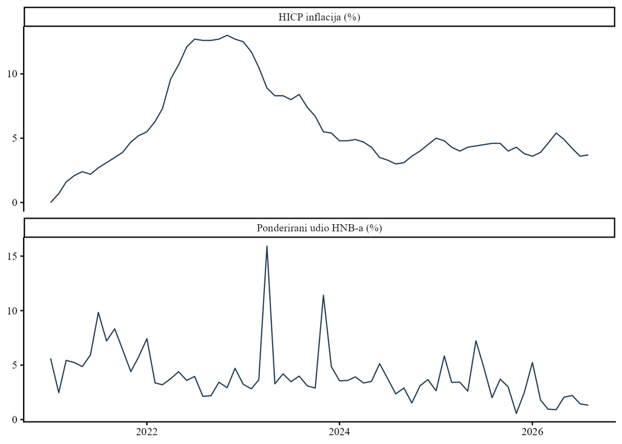

Slika 1: Mjesečni ponderirani udio HNB-a i hrvatska HICP inflacija, siječanj 2021. - kolovoz 2026. Paneli koriste zasebne ljestvice.

## 5.2 Inflacija i jaz u pažnji

U osnovnom tjednom modelu koeficijent inflacije iznosi 0,25 postotnih bodova jaza po jednom postotnom bodu inflacije, uz interval od 0,11 do 0,39 i $p$ < 0,001. Model koristi 295 regresijskih opažanja. Mjesečni model daje 0,27 postotnih bodova, uz interval od 0,08 do 0,47 i 67 opažanja. Pozitivan predznak znači da je viša inflacija povezana s nižim ponderiranim udjelom institucije, uvjetno na uključene regresore. Broj regresijskih opažanja manji je za jedan od broja potpunih razdoblja jer model uključuje promjenu inflacije.

Uključivanje obujma bitno je za veličinu i preciznost procjene. Bez te kontrole nagib iznosi 0,12 postotnih bodova tjedno i 0,17 mjesečno, a oba 95-postotna intervala uključuju nulu. Koeficijent osnovnog modela zato opisuje usporedbu razdoblja s jednakim kontroliranim obujmom institucionalnog korpusa; ne predstavlja ukupnu povezanost svih promjena u medijskom sustavu s inflacijom.

| Frekvencija | Obujam | N | Koef. (p. b.) | 95% interval | p |
| --- | --- | --- | --- | --- | --- |
| Mjesečno | Ne | 67 | 0,172 | [-0,012; 0,357] | 0,066 |
| Mjesečno | Da | 67 | 0,272 | [0,077; 0,467] | 0,007 |
| Tjedno | Ne | 295 | 0,124 | [-0,018; 0,265] | 0,086 |
| Tjedno | Da | 295 | 0,248 | [0,105; 0,391] | <0,001 |

Tablica 2: Inflacijski koeficijent u osnovnim modelima jaza

Za predodžbu veličine, razlika između inflacije od 2 i 10 posto povezana je s 1,98 postotnih bodova razlike u jazu prema osnovnom tjednom modelu, uz ostale regresore fiksne. Ta usporedba nije prognoza ni učinak intervencije. Početna tjedna referenca iznosi 5,16 posto; raspon inflacijskog scenarija i fiksna referenca imaju različite uloge u interpretaciji.

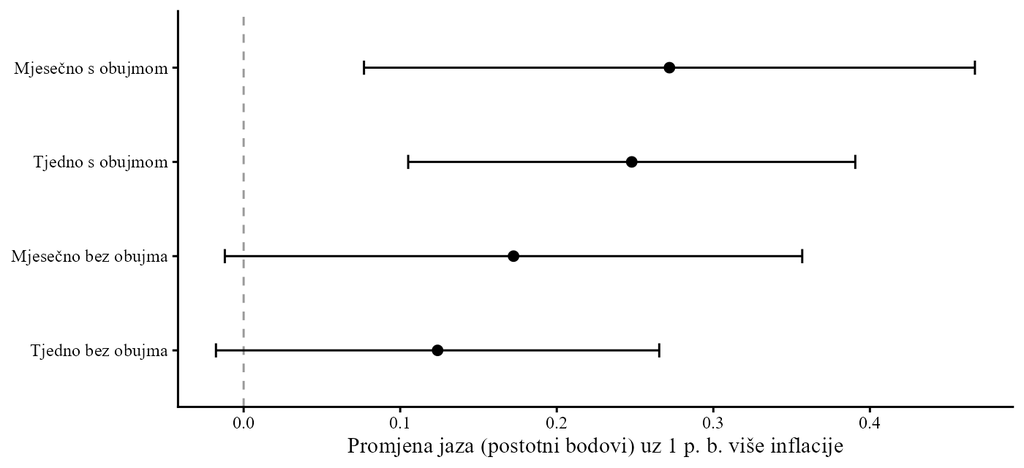

Slika 2: Koeficijenti inflacije i 95-postotni HAC intervali. Ishod je jaz izražen u postotnim bodovima.

## 5.3 Broj objava, doseg i mrežni položaj

Ekstenzivna margina daje najjasniji dodatni nalaz. Jedan postotni bod više inflacije povezan je s 0,65 postotnih bodova nižim omjerom relevantnih institucionalnih objava prema inflacijskim objavama tjedno te s 0,58 postotnih bodova nižim omjerom mjesečno. Oba su koeficijenta statistički razlučiva od nule uz kontrolu obujma. To podupire opis relativnog istiskivanja kroz broj objava: institucionalno relevantan sadržaj zauzima manji dio šireg tematskog toka.

Koeficijenti intenzivne margine negativni su na obje frekvencije, ali njihovi 95-postotni intervali uključuju nulu. Jednako tako, koeficijenti mrežne centralnosti nisu razlučivi od nule. Podaci stoga ne opravdavaju tvrdnju da viša inflacija istodobno i pouzdano smanjuje relativni doseg svake objave ili mrežnu centralnost HNB-a. Mjerenje tih dimenzija zasebno sprječava da se nalaz o broju objava proširi na ishode koje analiza nije potvrdila.

| Frekvencija | Ishod | N | Koeficijent | 95% interval | p |
| --- | --- | --- | --- | --- | --- |
| Mjesečno | Ekstenzivna margina | 67 | -0,0058 | [-0,0102; -0,0014] | 0,011 |
| Mjesečno | Intenzivna margina | 67 | -0,0076 | [-0,0164; 0,0013] | 0,093 |
| Mjesečno | Centralnost | 67 | 0,0035 | [-0,0062; 0,0132] | 0,472 |
| Tjedno | Ekstenzivna margina | 295 | -0,0065 | [-0,0097; -0,0034] | <0,001 |
| Tjedno | Intenzivna margina | 295 | -0,0032 | [-0,0092; 0,0028] | 0,291 |
| Tjedno | Centralnost | 295 | 0,0040 | [-0,0019; 0,0099] | 0,180 |

Tablica 3: Inflacija i dodatne dimenzije zastupljenosti, uz kontrolu obujma

Tablica 3 prikazuje koeficijente u izvornim jedinicama pojedinoga ishoda. Veća brojčana vrijednost koeficijenta intenzivne margine ne znači da je taj mehanizam važniji od broja objava. Mrežna centralnost dodatno ovisi o zastupljenosti drugih aktera i strukturi izvora te se ne može izjednačiti s ponderiranim udjelom u inflacijskom nazivniku.

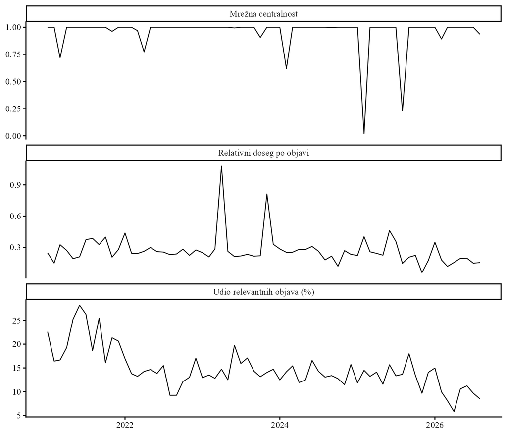

Slika 3: Mjesečna ekstenzivna margina, intenzivna margina i svojstvena centralnost HNB-a. Svaki panel koristi vlastitu ljestvicu.

## 5.4 Osjetljivost osnovnoga nalaza

Svih sedam alternativnih definicija mjere zadržava pozitivan koeficijent inflacije i 95-postotni interval iznad nule na obje frekvencije. Tjedne procjene kreću se od 0,13 postotnih bodova uz širi inflacijski nazivnik do 0,35 uz stalne izvore. Uži korpus koji zahtijeva izričit HNB daje 0,24 postotna boda, blizu osnovne procjene od 0,25. Isključivanje sindiciranih institucionalnih objava smanjuje koeficijent na 0,16, ali ga ne svodi na nulu. Nalaz dakle nije ograničen na jednu definiciju naziva institucije, imputaciju dosega ili izbor pondera istaknutosti.

Vremenske kontrole otkrivaju važniju granicu. Linearni trend i kalendarska sezonalnost zadržavaju pozitivan, statistički razlučiv nagib. Uz godišnje indikatore tjedni koeficijent pada na 0,14 postotnih bodova, uz interval od −0,12 do 0,41; mjesečni iznosi 0,22, uz interval od −0,05 do 0,49. Ne možemo pouzdano izdvojiti povezanost unutar godina od širih razlika među godinama. Kontrola državne komunikacije također smanjuje nagib: tjedna procjena ostaje razlučiva od nule, dok mjesečna ne ostaje. Sentiment, vlastite objave HNB-a te raniji završetci uzorka zadržavaju pozitivan i statistički razlučiv koeficijent. Sve zajedno podupire postojanost predznaka kroz mjerne definicije, uz osjetljivost snage zaključka na uvjetovanje i vremensku strukturu.

| Specifikacija | N | Koef. (p. b.) | 95% interval | p |
| --- | --- | --- | --- | --- |
| Izričito imenovan HNB | 295 | 0,239 | [0,102; 0,375] | <0,001 |
| Izvorne objave u brojniku | 295 | 0,158 | [0,051; 0,266] | 0,004 |
| Jednaki ponderi istaknutosti | 295 | 0,257 | [0,108; 0,406] | <0,001 |
| Samo opaženi doseg | 295 | 0,246 | [0,104; 0,388] | <0,001 |
| Stalni izvori | 295 | 0,349 | [0,191; 0,507] | <0,001 |
| Ograničeni ekstremni dosezi | 295 | 0,198 | [0,076; 0,319] | 0,002 |
| Širi inflacijski nazivnik | 295 | 0,129 | [0,015; 0,243] | 0,026 |
| Uz sentiment | 295 | 0,228 | [0,088; 0,368] | 0,001 |
| Uz linearni trend | 295 | 0,257 | [0,109; 0,405] | <0,001 |
| Uz godišnje indikatore | 295 | 0,143 | [-0,121; 0,407] | 0,286 |
| Uz kalendarske mjesece | 295 | 0,277 | [0,138; 0,415] | <0,001 |
| Uz HNB-ove objave | 295 | 0,252 | [0,111; 0,392] | <0,001 |
| Uz državnu komunikaciju | 295 | 0,168 | [0,025; 0,310] | 0,021 |
| Do prosinca 2023. | 155 | 0,352 | [0,177; 0,527] | <0,001 |
| Do svibnja 2026. | 281 | 0,261 | [0,119; 0,404] | <0,001 |

Tablica 4: Tjedne procjene uz alternativne pokazatelje i kontrole

Promjena institucijskog brojnika mijenja sadržaj mjere. Uži izričiti HNB manje je izložen generičkim spominjanjima stranih banaka, ali može propustiti tekst koji jasno raspravlja o domaćoj instituciji bez ponavljanja njezina naziva. U toj varijanti zadržavamo postojeći ponder istaknutosti, a mijenjamo odabir objava; to nije zasebno validirana procjena uloge svake imenovane banke. Varijanta stalnih izvora ograničava ulazak i izlazak naziva izvora; ne izjednačava njihov obujam, publiku ili uređivački odabir. Ponderi opaženoga dosega provjeravaju ulogu imputacije, uz mogućnost selektivnog izostanka dosega.

## 5.5 Zastupljenost tijekom 2024.-2026.

Tijekom 2024.-2026. glavni jaz raste i nakon kontrole inflacije i ostalih osnovnih regresora. Mjesečni trend iznosi 0,092 postotna boda po mjesecu, uz interval od 0,037 do 0,147; tjedni iznosi 0,019 postotnih bodova po tjednu. To znači da niža relativna zastupljenost u kasnijem dijelu uzorka nije samo preslikavanje tekuće razine inflacije u osnovnoj specifikaciji.

Uz stalne izvore trend je manji. Mjesečno iznosi 0,040 postotnih bodova i nije statistički razlučiv od nule, dok tjedno iznosi 0,009 i ostaje razlučiv. Smjer je sličan, ali dokaz o kasnijoj putanji ovisi o izboru izvora i frekvenciji. Centralnost nema statistički razlučiv trend ni na jednoj frekvenciji. Stoga nalaz opisujemo kao nastavak niske relativne zastupljenosti u glavnom korpusu, bez zaključka o trajnom gubitku mrežnog položaja ili uzročno dokazanoj histerezi.

| Frekvencija | Ishod | N | Trend | 95% interval | p |
| --- | --- | --- | --- | --- | --- |
| Mjesečno | Jaz | 31 | 0,00092 | [0,00037; 0,00147] | 0,002 |
| Mjesečno | Jaz, stalni izvori | 31 | 0,00040 | [-0,00010; 0,00091] | 0,111 |
| Mjesečno | Centralnost | 31 | 0,00364 | [-0,00196; 0,00924] | 0,193 |
| Tjedno | Jaz | 139 | 0,00019 | [0,00011; 0,00026] | <0,001 |
| Tjedno | Jaz, stalni izvori | 139 | 0,00009 | [0,00001; 0,00017] | 0,025 |
| Tjedno | Centralnost | 139 | 0,00016 | [-0,00079; 0,00111] | 0,741 |

Tablica 5: Uvjetni vremenski trend tijekom 2024.-2026.

Tablica 5 prikazuje trendove jaza u izvornim jedinicama udjela po mjesecu ili tjednu. Koeficijente treba pomnožiti sa sto za postotne bodove. Razdoblje 2024.-2026. odabrano je kao kasniji gospodarski prozor; njegov trend ne identificira učinak prethodnog inflacijskog šoka.

## 5.6 Dinamika i očekivanja potrošača

Modeli prvih razlika ne daju statistički razlučivu vezu promjene inflacije s promjenom jaza: mjesečni $p$ iznosi 0,167, a tjedni 0,984. Povezanost među razinama zato se ne može bez dodatnog dokaza prenijeti na kratkoročne promjene. U opisnoj korekciji odstupanja koeficijent prethodnoga reziduala negativan je i razlučiv od nule, približno −0,85 mjesečno i −0,76 tjedno. To pokazuje povratak nakon odstupanja od procijenjenog odnosa u ovom uzorku. Bez zasebnih provjera dugoročnoga odnosa i neizvjesnosti oba koraka te koeficijente ne tumačimo kao dokaz kointegracije niti strukturnu brzinu prilagodbe.

| Serija | Pokazatelj | Model | Znacajni | Horizonti |
| --- | --- | --- | --- | --- |
| Mjesečna | Jaz | Osnovni | 0 | - |
| Mjesečna | Jaz | Prošireni | 0 | - |
| Mjesečna | Ekstenzivna | Osnovni | 5 | 8, 9, 10, 11, 12 |
| Mjesečna | Ekstenzivna | Prošireni | 3 | 8, 9, 11 |
| Tjedna stepenasta | Jaz | Osnovni | 0 | - |
| Tjedna stepenasta | Jaz | Prošireni | 0 | - |
| Tjedna stepenasta | Ekstenzivna | Osnovni | 2 | 1, 2 |
| Tjedna stepenasta | Ekstenzivna | Prošireni | 0 | - |
| Tjedna linearna | Jaz | Osnovni | 0 | - |
| Tjedna linearna | Jaz | Prošireni | 4 | 1, 2, 3, 4 |
| Tjedna linearna | Ekstenzivna | Osnovni | 1 | 1 |
| Tjedna linearna | Ekstenzivna | Prošireni | 4 | 1, 2, 3, 4 |

Tablica 6: Broj značajnih budućih horizonata od 1 do 12 nakon korekcije za 13 testova

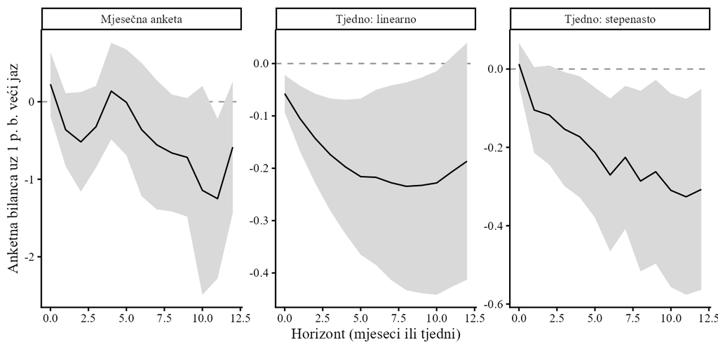

Slika 4: Lokalne projekcije anketne bilance uz jedan postotni bod veći jaz, prošireni model. Sjenčanje pokazuje točkaste 95-postotne intervale; zaključci o višestrukim horizontima koriste korigirane testove iz tablice.

Za jaz ne nalazimo značajan budući horizont nakon korekcije višestrukih testova u izvornoj mjesečnoj anketnoj seriji, ni u osnovnom ni u proširenom modelu. Isti rezultat vrijedi za stepenasto pridruživanje anketnih vrijednosti tjednima. Kod linearno interpolirane tjedne serije prošireni model daje negativnu povezanost na horizontima od jednog do četiri tjedna. Taj nalaz ne ponavlja se u ostalim prikazima anketnih podataka, pa ga ne smatramo stabilnim dokazom veze jaza i budućih očekivanja.

Za ekstenzivnu marginu postoje značajni horizonti, ali njihovo značenje nije jednoznačno. Mjesečni modeli daju pozitivnu povezanost na kasnijim horizontima: od osmog do dvanaestog mjeseca u osnovnom modelu te u osmom, devetom i jedanaestom mjesecu u proširenom. Osnovni tjedni modeli pokazuju negativnu kratkoročnu povezanost, dok prošireni model linearno interpolirane serije daje pozitivnu povezanost od prvog do četvrtog tjedna. Razlike predznaka, vremenskog horizonta i obrade serije upućuju na osjetljivost rezultata. Medijska zastupljenost i anketna očekivanja u ovim podacima ne tvore jednostavan, stabilan prijenosni kanal.

## 5.7 Instrumenti i institucionalna specifičnost

IV koeficijenti zadržavaju pozitivan predznak: tjedne procjene iznose 0,23 postotna boda uz eurozonsku prehrambenu i energetsku inflaciju te 0,26 uz godišnju promjenu FAO indeksa. Mjesečne procjene iznose 0,26 i 0,45. Svi prikazani intervali isključuju nulu, a statistike prvog stupnja upućuju na snažnu prediktivnu povezanost instrumenata s hrvatskom inflacijom u ovom uzorku.

Ipak, oba instrumentna skupa predviđaju zastupljenost HANFA-e u tjednoj dijagnostici i nakon kontrole hrvatske inflacije: pripadni $p$ iznose 0,018 i 0,034. U mjesečnoj dijagnostici iznose 0,058 i 0,195. Tjedni nalaz upozorava da instrumenti mogu zahvaćati šire financijske i medijske okolnosti. IV procjene stoga ostaju provjera osjetljivosti, a ne dokaz uzročnog učinka inflacije na institucionalni jaz.

| Frekvencija | Instrument | N | Koef. (p. b.) | 95% interval | p |
| --- | --- | --- | --- | --- | --- |
| Mjesečno | EA hrana i energija | 67 | 0,260 | [0,067; 0,453] | 0,009 |
| Mjesečno | FAO | 67 | 0,455 | [0,245; 0,664] | <0,001 |
| Tjedno | EA hrana i energija | 295 | 0,233 | [0,078; 0,387] | 0,003 |
| Tjedno | FAO | 295 | 0,264 | [0,042; 0,486] | 0,020 |

Tablica 7: IV procjene kao provjera osjetljivosti

Cijene hrane i energije mogu izravno utjecati na izbor medijskih tema. Relevancija instrumenata zato ne potvrđuje pretpostavku isključenja. HANFA također nije institucija s identičnim zadaćama niti savršen kontrafaktual za HNB. Te provjere služe ograničavanju interpretacije, a ne automatskoj pretvorbi uvjetne povezanosti u uzročni učinak.

# 6 Rasprava

Rezultati daju tri različita odgovora na početna pitanja. Prvo, viša inflacija povezana je s većim jazom u glavnim mjesečnim i tjednim modelima, a taj predznak ne ovisi o jednoj definiciji medijskog korpusa. Drugo, najjasniji dodatni nalaz odnosi se na relativni broj institucionalno relevantnih objava, dok intenzivna margina i mrežna centralnost ne daju podjednako uvjerljiv obrazac. Treće, povezanost s budućim anketnim očekivanjima ovisi o frekvenciji, interpolaciji i kontrolama. Nema osnove da te tri razine spojimo u tvrdnju da inflacija uzrokuje slabiju komunikaciju i preko nje neusidrena očekivanja.

Osjetljivost na godišnje indikatore i kontrolu obujma određuje doseg glavnog nalaza. Razlike među godinama nose važan dio opažene povezanosti, a kontroliranje broja institucionalnih objava mijenja usporedbu koju model procjenjuje. S druge strane, uži odabir institucionalnih objava, stalni izvori, opaženi doseg i alternativni ponderi zadržavaju pozitivan koeficijent. Najprimjereniji zaključak jest da u ovom korpusu postoji mjerljiva, uvjetna povezanost inflacije i relativne institucionalne zastupljenosti, čije se uzročno podrijetlo ne može utvrditi ovim vremenskim modelima.

Korisnost pokazatelja proizlazi iz razdvajanja institucionalne aktivnosti od relativne zastupljenosti. Središnja banka može objavljivati priopćenja i biti redovito citirana, dok ukupni prostor posvećen inflaciji raste još brže. Sam broj spominjanja ne otkriva taj odnos. Ponderirani udio dodaje informaciju o položaju institucije u promatranom tematskom prostoru, ali zahtijeva jasnu definiciju brojnika, nazivnika i dosega.

Za praksu to znači da praćenje objava može uključiti najmanje tri zasebne veličine: obujam vlastite komunikacije, relativni prostor u medijima i sadržaj prenesenog objašnjenja. Ni jednu od njih ne treba unaprijed poistovjetiti s razumijevanjem publike. Daljnja analiza narativa mogla bi ispitati koje se objašnjenje inflacije prenosi, koji uzroci i odgovornosti dominiraju te zadržava li tekst uvjete i neizvjesnosti iz izvornog institucionalnog objašnjenja.

Automatizirana jezična obrada može pomoći razlikovanju institucija, procjeni njihove uloge i analizi tona. Za takvo proširenje potrebno je unaprijed definirati kategorije, neovisno ljudski kodirati uzorak i provjeriti pogreške po razdobljima i vrstama izvora. Ovaj rad ne predstavlja završenu validaciju velikoga jezičnog modela. Pravila istaknutosti i dobavljačev sentiment ostaju operativne mjere s različitim izvorima pogreške.

Važna ograničenja odnose se na sadržaj podataka i identifikaciju. Potencijalni doseg nije stvarna izloženost, a automatsko pronalaženje naziva ne jamči ispravnu institucionalnu atribuciju. Usporedba različitih pondera i užeg korpusa otkriva dio te osjetljivosti. Tjedno ponavljanje mjesečne inflacije ne povećava broj neovisnih makroekonomskih opažanja; zbog toga usporedno prikazujemo mjesečne modele i alternative inferenciji. Napokon, kontrolne varijable mogu biti dio procesa nastanka medijske zastupljenosti, pa njihovo uključivanje ne uklanja automatski endogenost.

# 7 Zaključak

Na cijelom rasponu potpunih mjeseci od siječnja 2021. do kolovoza 2026. viša inflacija povezana je s većim institucionalnim jazom u pažnji HNB-a u osnovnoj specifikaciji. Jedan postotni bod više inflacije odgovara približno 0,25 postotnih bodova većem jazu tjedno i 0,27 mjesečno. Alternativne definicije korpusa, istaknutosti i dosega zadržavaju pozitivan nalaz, dok godišnji indikatori i izostavljanje kontrole obujma proširuju intervale preko nule. Riječ je o uvjetnoj povezanosti, bez identificiranog uzročnog učinka.

Najizraženiji obrazac jest manji relativni broj relevantnih institucionalnih objava pri višoj inflaciji. Kasniji godišnji udjeli ostaju niski, ali to ne prati pouzdano slabljenje mrežne centralnosti niti stabilna veza jaza s budućim anketnim očekivanjima. Doprinos pokazatelja jest učiniti tu razliku vidljivom: učestalost spominjanja, relativni prostor u inflacijskom diskursu i reakcija publike zahtijevaju zasebno mjerenje. Takav pristup omogućuje preciznije praćenje institucionalne zastupljenosti i postavlja jasne zahtjeve pred buduću analizu sadržaja i učinaka komunikacije.

# Dostupnost podataka i koda

Agregirani mjesečni i tjedni paneli, procjene, intervali, projekcije i provjere dostupni su uz ovaj rukopis u direktoriju `results/refresh_20260928`. Skripte u `analysis/refresh_20260928` ponovno izdvajaju podatke, računaju pokazatelje i procjenjuju modele. Manifest ulaza, zapis programskog okruženja i provjere aritmetike i inferencije omogućuju ponavljanje analize. Izvorni tekstovi i osobni metapodatci ostaju izvan distribucije. HTML i PDF nastaju iz istog izvornog rukopisa i istih spremljenih rezultata.

# Literatura

Bracha, A., i Tang, J. (2019). *Inflation Thresholds and Inattention*. ( br. 19-14) Federal Reserve Bank of Boston. https://doi.org/10.29412/res.wp.2019.14.

Coibion, O., Gorodnichenko, Y., i Weber, M. (2022). Monetary Policy Communications and Their Effects on Household Inflation Expectations. *Journal of Political Economy*, *130*(6), 1537–1584. https://doi.org/10.1086/718982.

Entman, R. M. (1993). Framing: Toward Clarification of a Fractured Paradigm. *Journal of Communication*, *43*(4), 51–58.

Food and Agriculture Organization of the United Nations. (2026). FAO Food Price Index. https://www.fao.org/worldfoodsituation/foodpricesindex/en/.

Jordà, Ò. (2005). Estimation and Inference of Impulse Responses by Local Projections. *American Economic Review*, *95*(1), 161–182. https://doi.org/10.1257/0002828053828518.

Malmendier, U., i Nagel, S. (2016). Learning from Inflation Experiences. *The Quarterly Journal of Economics*, *131*(1), 53–87. https://doi.org/10.1093/qje/qjv037.

Mankiw, N. G., i Reis, R. (2002). Sticky Information Versus Sticky Prices: A Proposal to Replace the New Keynesian Phillips Curve. *Quarterly Journal of Economics*, *117*(4), 1295–1328.

Newey, W. K., i West, K. D. (1987). A Simple, Positive Semi-Definite, Heteroskedasticity and Autocorrelation Consistent Covariance Matrix. *Econometrica*, *55*(3), 703–708. https://www.nber.org/papers/t0055.

Shoemaker, P. J., i Vos, T. P. (2009). *Gatekeeping Theory*. Routledge.

Sims, C. A. (2003). Implications of Rational Inattention. *Journal of Monetary Economics*, *50*(3), 665–690.

Woodford, M. (2003). *Interest and Prices: Foundations of a Theory of Monetary Policy*. Princeton University Press.

# 8 Dodatne numeričke provjere

## 8.1 Deskriptivna statistika mjesečnih pokazatelja

| Pokazatelj | N | Prosjek | SD | Minimum | Maksimum |
| --- | --- | --- | --- | --- | --- |
| Jaz | 68 | 0,0084 | 0,0246 | -0,1099 | 0,0436 |
| Ponderirani udio | 68 | 0,0408 | 0,0246 | 0,0056 | 0,1591 |
| Ekstenzivna margina | 68 | 0,1472 | 0,0424 | 0,0582 | 0,2819 |
| Intenzivna margina | 68 | 0,2701 | 0,1419 | 0,0580 | 1,0784 |
| Centralnost | 68 | 0,9561 | 0,1605 | 0,0197 | 1,0000 |
| HICP (%) | 68 | 5,8309 | 3,3247 | 0,0000 | 13,0000 |
| Koncentracija | 68 | 0,0896 | 0,0417 | 0,0334 | 0,2367 |
| Negativni sentiment | 68 | 0,5987 | 0,1126 | 0,1464 | 0,7820 |
| Log obujma | 68 | 7,4638 | 0,2983 | 6,8469 | 8,2667 |

Tablica 8: Mjesečne deskriptivne statistike u izvornim jedinicama

## 8.2 Mjesečne analize osjetljivosti

| Specifikacija | N | Koef. (p. b.) | 95% interval | p |
| --- | --- | --- | --- | --- |
| Izričito imenovan HNB | 67 | 0,254 | [0,073; 0,435] | 0,007 |
| Izvorne objave u brojniku | 67 | 0,185 | [0,039; 0,331] | 0,014 |
| Jednaki ponderi istaknutosti | 67 | 0,284 | [0,081; 0,486] | 0,007 |
| Samo opaženi doseg | 67 | 0,269 | [0,075; 0,463] | 0,007 |
| Stalni izvori | 67 | 0,376 | [0,184; 0,568] | <0,001 |
| Ograničeni ekstremni dosezi | 67 | 0,214 | [0,055; 0,373] | 0,009 |
| Širi inflacijski nazivnik | 67 | 0,158 | [0,030; 0,285] | 0,016 |
| Uz sentiment | 67 | 0,262 | [0,066; 0,459] | 0,010 |
| Uz linearni trend | 67 | 0,262 | [0,089; 0,435] | 0,004 |
| Uz godišnje indikatore | 67 | 0,216 | [-0,053; 0,485] | 0,113 |
| Uz kalendarske mjesece | 67 | 0,321 | [0,127; 0,515] | 0,002 |
| Uz HNB-ove objave | 67 | 0,271 | [0,083; 0,459] | 0,005 |
| Uz državnu komunikaciju | 67 | 0,139 | [-0,073; 0,350] | 0,196 |
| Do prosinca 2023. | 35 | 0,369 | [0,134; 0,605] | 0,003 |
| Do svibnja 2026. | 64 | 0,284 | [0,093; 0,476] | 0,004 |

Tablica 9: Mjesečni koeficijenti uz alternativne pokazatelje i kontrole

## 8.3 Standardne pogreške i utjecaj pojedinih mjeseci

| Postupak | SE (p. b.) | 95% interval | p |
| --- | --- | --- | --- |
| HAC, širina 1 | 0,058 | [0,134; 0,362] | <0,001 |
| HAC, širina 3 | 0,065 | [0,120; 0,376] | <0,001 |
| HAC, širina 5 | 0,070 | [0,110; 0,386] | <0,001 |
| HAC, širina 8 | 0,078 | [0,095; 0,401] | 0,002 |
| HAC, širina 12 | 0,085 | [0,080; 0,416] | 0,004 |
| HAC, širina 26 | 0,091 | [0,070; 0,426] | 0,007 |
| Grupiranje po mjesecu | 0,066 | [0,115; 0,381] | <0,001 |

Tablica 10: Osjetljivost tjedne inferencije

Pri izostavljanju pojedinih mjeseci tjedni nagib kreće se od 0,218 do 0,281 postotnih bodova, a mjesečni od 0,239 do 0,304. Blokovna permutacija s 1.999 ponavljanja daje $p$ = 0,002 tjedno i $p$ = 0,005 mjesečno. Permutiraju se reziduali ograničenoga modela uz zadržane kontrole; to nije randomizacijska inferencija iz nasumično dodijeljenog tretmana.

## 8.4 Kratkoročna dinamika

| Frekvencija | Model | N | Koeficijent | 95% interval | p |
| --- | --- | --- | --- | --- | --- |
| Mjesečno | Prve razlike | 67 | 0,0086 | [-0,0037; 0,0209] | 0,167 |
| Mjesečno | Korekcija odstupanja | 65 | -0,8522 | [-1,3584; -0,3461] | 0,001 |
| Tjedno | Prve razlike | 295 | 0,0001 | [-0,0147; 0,0150] | 0,984 |
| Tjedno | Korekcija odstupanja | 293 | -0,7599 | [-0,9430; -0,5769] | <0,001 |

Tablica 11: Prve razlike i opisna korekcija odstupanja

U prvim razlikama tablica prikazuje koeficijent promjene inflacije. U korekciji odstupanja prikazuje koeficijent prethodnoga reziduala odnosa među razinama. To su različiti parametri s različitim tumačenjem.

## 8.5 Relevancija instrumenata i provjera s HANFA-om

| Frekvencija | Instrument | Wald F | p prvi stupanj | p HANFA |
| --- | --- | --- | --- | --- |
| Mjesečno | EA hrana i energija | 185,93 | <0,001 | 0,058 |
| Mjesečno | FAO | 36,37 | <0,001 | 0,195 |
| Tjedno | EA hrana i energija | 405,94 | <0,001 | 0,018 |
| Tjedno | FAO | 49,17 | <0,001 | 0,034 |

Tablica 12: Prvi stupanj i prediktivnost instrumenata za HANFA-u

Waldova statistika prvoga stupnja podijeljena je brojem isključenih instrumenata. Ne poistovjećujemo je s formalnim efektivnim F-testom i njegovim kritičnim vrijednostima. Test za HANFA-u uvjetuje na hrvatskoj inflaciji i osnovnim kontrolama; njegova interpretacija ostaje dijagnostička.